# Chapter code for Applied Predictive Modeling (Kuhn and Johnson, 2013)

Chapter 8

by Brian Hassett

# Chapter 8 Regression Trees and Rule-Based Models

This is a `tidymodels` implementation of the code in **Chapter 8** of **Applied Predictive Modeling** by Max Kuhn and Kjell Johnson[^1]. I have already implemented all code and models from this chapter using mainly the `caret` package in a separate notebook, `APM_8.Rmd`. In that notebook I used the `solTrainXtrans` data set as the training data. This data set has already had a transformation applied to it (Box-Cox). In this notebook I have used the full data set (un-transformed) and did the Box-Cox transformation and data splitting myself using the appropriate recipe.

## Setup

```r
# Load packages:
library(AppliedPredictiveModeling)
library(caret)
library(tidyverse)
library(tidymodels)
library(patchwork)
library(baguette)
library(rules)
# Load my functions:
source("/home/brian/R/dir/Util/bh_functions.R")

# Options:
theme_set(theme_bw())
options(digits = 4)
```

## Load and Split Data

The `tidymodels` process has its own functions for splitting data. Combine the pre-split training and test data from the `solubility` data into one data frame, then use the `tidymodels` functions to split the data:

```r
# Load data:
data(solubility)

# Combine the data sets (update the name of the outcome vectors to y so that they are the same).
# Also give the data frame a generic name.
df1 <- rbind(
  cbind(y = solTrainY, solTrainX), # training data
  cbind(y = solTestY, solTestX) # test data
)

# Split data:
set.seed(1)
splits <- initial_split(df1) # default prop is 3/4
df_train <- training(splits)
df_test <- testing((splits))

# Create folds for 10-fold cross-validation:
folds <- vfold_cv(df_train, v = 10)
```

## Data Summary

No missing data, and all variables are numeric:

```r
bh_print_data_summary(df1)
```

```
                      [,1]
num_rows              "  1,267"
num_cols              "    229"
num_categorical_cols  "      0"
num_numeric_cols      "    229"
all_missing_cols      "      0"
complete_cols         "    229"
total_missing         "      0"
total_percent_missing "      0"
total_data_points     "290,143"
size_MB               "      1"
```

## Distribution of outcome variable

The outcome variable is not too skewed:

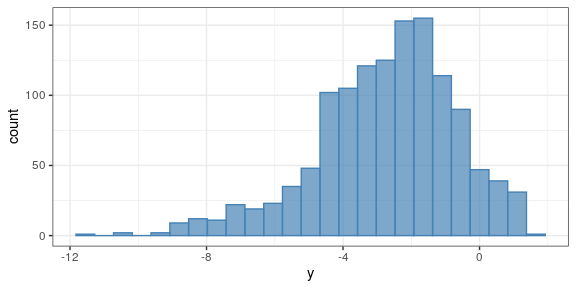

```r
df1 %>%
  ggplot() +
  geom_histogram(aes(y), bins = 25,
                 fill = "steelblue", color = "steelblue", alpha = 0.7)
```

## 8.1 Basic Regression Trees

## CART trees

### Training Data

Build a basic regression tree (CART) model and train using cross-validation:

```r
# Recipe:
rec1 <-
  recipe(y ~ ., data = df_train) %>%
  step_BoxCox(all_numeric(), -all_outcomes())

# Model:
cart_mod <-
  decision_tree(cost_complexity = tune()) %>% # `tree_depth` (30) and `min_n` (20) are left at their defaults (as was done with the `caret` model)
  set_engine("rpart") %>%
  set_mode("regression")

# Workflow:
workflow1 <-
  workflow() %>%
  add_model(spec = cart_mod) %>%
  add_recipe(recipe = rec1)

# Create a tuning grid with the same candidate values as the `caret` model (in `APM_8.R`):
# Read in the grid of values used in the `caret` model (it was auto-generated by `caret` so hard to specify it separately here)
cp <- readRDS("/home/brian/R/dir/APM/chapter8/data/APM_8_cartTune.RDS")$results$cp
cart_grid <- expand.grid(cost_complexity = cp)

# Use `tune::tune_grid()` to combine the workflow and CV folds to fit the model on the training data:
## Read in cached results if available:
file1 <- "/home/brian/R/dir/APM/chapter8/data/cart_cv.RDS"
if (file.exists(file1)) {
  cart_cv <- readRDS(file1)
} else {
  cart_cv <-
    workflow1 %>%
    tune_grid(resamples = folds,
              grid = cart_grid,
              control = control_grid(save_pred = TRUE),
              metrics = metric_set(rmse, rsq))
  saveRDS(cart_cv, file1)
}
```

Plot CV results:

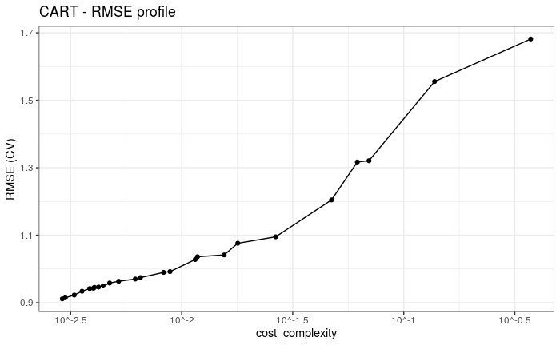

```r
cart_cv %>%
  collect_metrics() %>%
  filter(.metric == "rmse") %>%
  ggplot(aes(cost_complexity, mean)) +
  geom_point() +
  geom_line() +
  scale_x_continuous(trans = "log10",
                     breaks = 10^seq(-2.5, -0.5, 0.5),
                     labels = str_c("10^", seq(-2.5, -0.5, 0.5))) +
  labs(y = "RMSE (CV)", title = "CART - RMSE profile")
```

The results are similar to the `caret` workflow and text (Fig. 8.5).

Select the best model and store the training error:

```r
cart_best <- cart_cv %>%
  select_best("rmse")

# Store the training error:
rmse_train <- cart_cv %>%
  show_best("rmse") %>%
  pluck("mean", 1)
```

### Testing Data

Fit a model using all of the training data and apply it to the test data:

```r
# Finalize the workflow by updating it to use the best model:
final_wf <-
  workflow1 %>%
  finalize_workflow(cart_best)

# This extracts the parameters in the final model (this code is clunky, could probably be made simpler):
wf <- final_wf %>% workflows::pull_workflow_spec()
cost_complexity <- wf$args$cost_complexity[2] %>% as.character() %>% as.numeric() %>% round(6)
```

```
Subsetting quosures with `[` is deprecated as of rlang 0.4.0
Please use `quo_get_expr()` instead.
```

```r
# Fit the final model using all of the training data and evaluate using the test data:
cart_fit_final <-
  final_wf %>%
  last_fit(splits)

# Store test error:
rmse_test <- cart_fit_final %>%
  collect_metrics() %>%
  filter(.metric == "rmse") %>%
  pluck(".estimate")
```

Store the training and test RMSE values and parameters:

```r
RMSE_TM <- tibble(
  framework = "tidymodels",
  engine = "rpart",
  model = "CART",
  rmse_train = rmse_train,
  rmse_test = rmse_test,
  parameters = str_interp("cost_complexity: ${cost_complexity}")
)
```

### Variable importance

View the final CART tree model:

```r
final_fit1 <- fit(final_wf, df_train) %>%
  pull_workflow_fit()
final_fit1
```

```
parsnip model object

Fit time:  725ms
n= 951

node), split, n, deviance, yval
      * denotes terminal node

  1) root 951 4030.000 -2.7470
    2) NumCarbon>=3.858 315 1129.000 -4.5570
      4) SurfaceArea2< 1.62 79  197.300 -6.8490
        8) NumNonHBonds>=3.953 48   50.600 -7.8690
         16) NumNonHAtoms>=3.624 11   12.340 -8.9910 *
         17) NumNonHAtoms< 3.624 37   20.300 -7.5360 *
        9) NumNonHBonds< 3.953 31   19.430 -5.2700
         18) NumNonHAtoms>=3.096 17    4.040 -5.8710 *
         19) NumNonHAtoms< 3.096 14    1.784 -4.5400 *
      5) SurfaceArea2>=1.62 236  377.600 -3.7900
       10) HydrophilicFactor< 0.37 168  254.100 -4.0840
         20) MolWeight>=5.749 47   53.070 -4.8300
           40) SurfaceArea2< 39.17 9   12.250 -6.1480 *
           41) SurfaceArea2>=39.17 38   21.500 -4.5180 *
         21) MolWeight< 5.749 121  164.700 -3.7950
           42) NumHydrogen>=27.5 13   14.520 -5.2080 *
           43) NumHydrogen< 27.5 108  121.100 -3.6250
             86) FP189< 0.5 84   72.940 -3.8330 *
             87) FP189>=0.5 24   31.750 -2.8950
              174) NumMultBonds>=8.5 13    6.321 -3.6930 *
              175) NumMultBonds< 8.5 11    7.359 -1.9520 *
       11) HydrophilicFactor>=0.37 68   73.000 -3.0630
         22) FP012< 0.5 57   43.930 -3.2790 *
         23) FP012>=0.5 11   12.630 -1.9440 *
    3) NumCarbon< 3.858 636 1358.000 -1.8500
      6) MolWeight>=5.328 105  181.200 -3.4350
       12) SurfaceArea1< 41.08 46   55.030 -4.4150
         24) FP070>=0.5 20   13.470 -5.2890 *
         25) FP070< 0.5 26   14.530 -3.7420 *
       13) SurfaceArea1>=41.08 59   47.650 -2.6710
         26) FP012< 0.5 48   29.690 -2.8890 *
         27) FP012>=0.5 11    5.767 -1.7220 *
      7) MolWeight< 5.328 531  860.900 -1.5370
       14) SurfaceArea2< 1.62 118  122.500 -2.7850
         28) NumBonds>=3.729 37    9.939 -3.9460 *
         29) NumBonds< 3.729 81   39.810 -2.2540
           58) NumNonHBonds>=1.794 46   12.290 -2.6820 *
           59) NumNonHBonds< 1.794 35    8.005 -1.6910 *
       15) SurfaceArea2>=1.62 413  502.200 -1.1800
         30) NumCarbon>=2.64 233  168.700 -1.7610
           60) MolWeight>=4.923 138   99.640 -2.0630
            120) SurfaceArea1< 44.63 76   54.980 -2.3430 *
            121) SurfaceArea1>=44.63 62   31.370 -1.7190 *
           61) MolWeight< 4.923 95   38.230 -1.3230 *
         31) NumCarbon< 2.64 180  153.300 -0.4289
           62) MolWeight>=4.577 107   81.850 -0.8291
            124) FP168>=0.5 46   35.420 -1.2940 *
            125) FP168< 0.5 61   28.960 -0.4782 *
           63) MolWeight< 4.577 73   29.230  0.1577 *
```

Plot the variable importance measures:

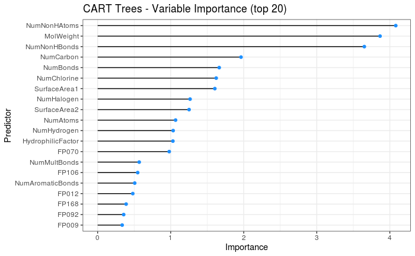

```r
varImp(final_fit1$fit) %>%
  filter(Overall > 0) %>%
  slice_max(Overall, n = 20) %>%
  rownames_to_column("var") %>%
  ggplot() +
  geom_segment(aes(x = 0, xend = Overall, y = reorder(var, Overall), yend = var)) +
  geom_point(aes(Overall, var), color = "dodgerblue") +
  labs(x = "Importance", y = "Predictor",
       title = "CART Trees - Variable Importance (top 20)")
```

## Conditional Inference Trees

The `tidymodels` framework does not yet include conditional inference trees. I have implemented them in a separate notebook using `caret` (`APM_8.Rmd`).

## 8.2 Regression Model Trees

The `tidymodels` framework does not yet include regression model trees. I have implemented them in a separate notebook using `caret` (`APM_8.Rmd`).

## 8.3 Rule-Based Methods

The `tidymodels` framework implements rule-based methods using the `rules` package. I’m not sure how to implement the same rule-based method as discussed in the book. See https://rules.tidymodels.org/index.html for more.

## 8.4 Bagged Trees

The `tidymodels` framework implements bagged models via the `baguette` package.

Build a *single* bagged CART tree model for the solubility data (as in `APM_8.Rmd` I will only use one value for the number of samples. Based on the docs for `baguette` I’m not sure it’s possible to tune for this number. If a grid of values is required a loop would be needed.)

### Training Data

I will use the same preprocessing recipe as the CART tree model (`rec1`):

```r
# Model:
times1 <- 50 # 50 ensemble members
bag_tree_mod <-
  bag_tree() %>% # parameters are left at the default
  set_engine("rpart", times = times1) %>% # 50 ensemble members
  set_mode("regression")

# Workflow:
workflow4 <-
  workflow() %>%
  add_model(spec = bag_tree_mod) %>%
  add_recipe(recipe = rec1)

# Fit the model:
## Use `fit_resamples()` to fit the data using CV (no tuning grid required here).
## Read in cached results if available:
file1 <- "/home/brian/R/dir/APM/chapter8/data/bag_tree_fit.RDS"
if (file.exists(file1)) {
  bag_tree_fit <- readRDS(file1)
} else {
  bag_tree_fit <-
    workflow4 %>%
    fit_resamples(folds)
  saveRDS(bag_tree_fit, file1)
}
```

Use `tune::collect_metrics()` to evaluate the model:

```r
collect_metrics(bag_tree_fit)
```

| .metric | .estimator | mean | n | std_err |
| --- | --- | --- | --- | --- |
| rmse | standard | 0.6586 | 10 | 0.021340 |
| rsq | standard | 0.8986 | 10 | 0.004838 |

There is only one value for each metric, which is the training error estimated via 10-fold cross-validation (which itself is the mean of 10 values).

Store the training error:

```r
rmse_train <- bag_tree_fit %>%
  show_best("rmse") %>%
  pluck("mean", 1)
```

### Testing Data

Fit the final model using all of the training data and evaluate using the test data:

```r
bag_tree_fit_final <-
  workflow4 %>%
  last_fit(splits)

# Store the test error:
rmse_test <- bag_tree_fit_final %>%
  collect_metrics() %>%
  filter(.metric == "rmse") %>%
  pluck(".estimate")
rmse_test
```

```
[1] 0.6719
```

Store the training and test RMSE values and parameters:

```r
RMSE_TM <- rbind(RMSE_TM,
                 c(framework = "tidymodels",
                   engine = "rpart",
                   model = "Bagged CART",
                   rmse_train = rmse_train,
                   rmse_test = rmse_test,
                   parameters = str_interp("times: ${times1}")))
```

## 8.5 Random Forests

The text implements random forests using CV and OOB estimates for evaluation of the models. They use CART trees and conditional inference trees. Since conditional inference trees aren’t implemented in `tidymodels` I will only implement CART tree models using both of the resampling methods.

First, a random forest with CART trees and 10-fold CV. Then a random forest with CART trees using OOB estimates.

## Random Forest with CART trees and 10-fold CV

### Training Data

```r
# Model:
rf_mod <-
  rand_forest(mtry = tune()) %>%
  set_engine("randomForest") %>%
  set_mode("regression")

# Workflow:
workflow5 <-
  workflow() %>%
  add_model(spec = rf_mod) %>%
  add_recipe(recipe = rec1)

# Create a tuning grid with the same candidate values as the `caret` model (in `APM_8.R`):
rf_grid <- data.frame(mtry = floor(seq(10, ncol(solTrainX), length = 10)))

# Use `tune::tune_grid()` to combine the workflow and CV folds to fit the model on the training data:
## Read in cached results if available:
file1 <- "/home/brian/R/dir/APM/chapter8/data/rf_cv.RDS"
if (file.exists(file1)) {
  rf_cv <- readRDS(file1)
} else {
  rf_cv <-
    workflow5 %>%
    tune_grid(resamples = folds,
              grid = rf_grid,
              control = control_grid(save_pred = TRUE),
              metrics = metric_set(rmse, rsq))
  saveRDS(rf_cv, file1)
}
```

Plot CV results:

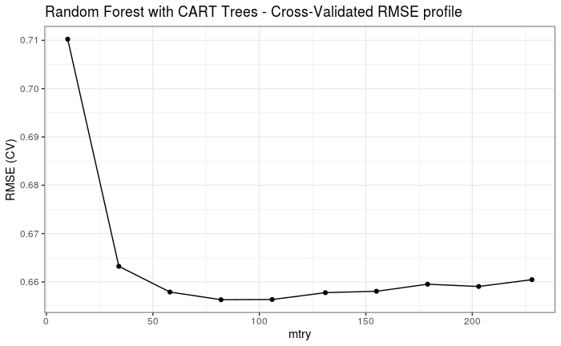

```r
rf_cv %>%
  collect_metrics() %>%
  filter(.metric == "rmse") %>%
  ggplot(aes(mtry, mean)) +
  geom_point() +
  geom_line() +
  labs(y = "RMSE (CV)", title = "Random Forest with CART Trees - Cross-Validated RMSE profile")
```

The results are very similar to the `caret` workflow and text (Fig. 8.18).

Select the best model and store the training error:

```r
rf_best <- rf_cv %>%
  select_best("rmse")

# Store the training error:
rmse_train <- rf_cv %>%
  show_best("rmse") %>%
  pluck("mean", 1)
```

### Testing Data

Fit a model using all of the training data and apply it to the test data:

```r
# Finalize the workflow by updating it to use the best model:
final_wf <-
  workflow5 %>%
  finalize_workflow(rf_best)

# This extracts the parameters in the final model (this code is clunky, could probably be made simpler):
wf <- final_wf %>% workflows::pull_workflow_spec()
mtry <- wf$args$mtry[2] %>% as.character()

# Fit the final model using all of the training data and evaluate using the test data:
rf_fit_final <-
  final_wf %>%
  last_fit(splits)

# Store test error:
rmse_test <- rf_fit_final %>%
  collect_metrics() %>%
  filter(.metric == "rmse") %>%
  pluck(".estimate")
```

Store the training and test RMSE values and parameters:

```r
RMSE_TM <- rbind(RMSE_TM,
                 c(framework = "tidymodels",
                   engine = "randomForest",
                   model = "Random Forest CART Trees - CV",
                   rmse_train = rmse_train,
                   rmse_test = rmse_test,
                   parameters = str_interp("mtry: ${mtry}")))
```

### Variable Importance

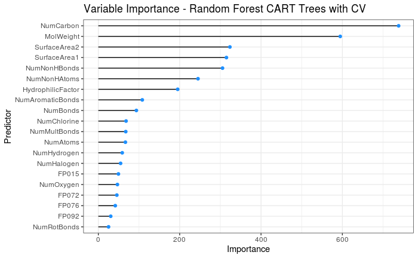

```r
final_fit5 <- fit(final_wf, df_train) %>%
  pull_workflow_fit()

varImp(final_fit5$fit) %>%
  filter(Overall > 0) %>%
  slice_max(Overall, n = 20) %>%
  rownames_to_column("var") %>%
  ggplot() +
  geom_segment(aes(x = 0, xend = Overall, y = reorder(var, Overall), yend = var)) +
  geom_point(aes(Overall, var), color = "dodgerblue") +
  labs(x = "Importance", y = "Predictor",
       title = "Variable Importance - Random Forest CART Trees with CV")
```

## Random Forest with CART trees and OOB estimation

The `caret` package uses 25 bootstrap samples by default, which is what I used in `APM_8.Rmd`. I will also use the same here.

### Training Data

The recipe, model, workflow and tuning grid are the same as before.

Create bootstrap samples and fit the model using those:

```r
# Bootstrap samples:
bootstrap_samples <- bootstraps(df_train, times = 25)

# Use `tune::tune_grid()` to combine the workflow and CV folds to fit the model on the training data:
## Read in cached results if available:
file1 <- "/home/brian/R/dir/APM/chapter8/data/rf_oob.RDS"
if (file.exists(file1)) {
  rf_oob <- readRDS(file1)
} else {
  rf_oob <-
    workflow5 %>%
    tune_grid(resamples = bootstrap_samples,
              grid = rf_grid,
              control = control_grid(save_pred = TRUE),
              metrics = metric_set(rmse, rsq))
  saveRDS(rf_oob, file1)
}
```

Plot results:

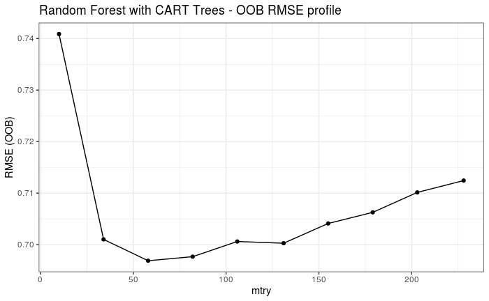

```r
rf_oob %>%
  collect_metrics() %>%
  filter(.metric == "rmse") %>%
  ggplot(aes(mtry, mean)) +
  geom_point() +
  geom_line() +
  labs(y = "RMSE (OOB)", title = "Random Forest with CART Trees - OOB RMSE profile")
```

The results are very similar to the `caret` workflow and text (Fig. 8.18).

Combine the CV and OOB random forests into one plot (as per Fig 8.18, page 201):

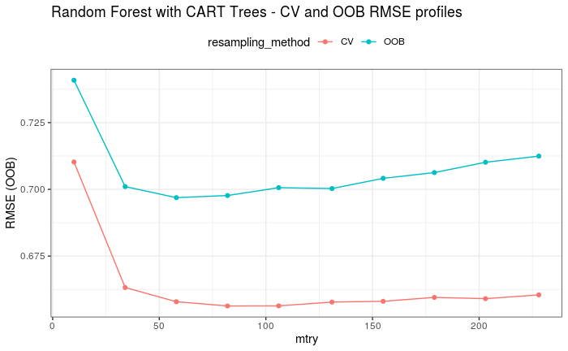

```r
rbind(
  collect_metrics(rf_cv) %>% mutate(resampling_method = "CV"),
  collect_metrics(rf_oob) %>% mutate(resampling_method = "OOB")
) %>%
  filter(.metric == "rmse") %>%
  ggplot(aes(mtry, mean, color = resampling_method)) +
  geom_point() +
  geom_line() +
  labs(y = "RMSE (OOB)", title = "Random Forest with CART Trees - CV and OOB RMSE profiles") +
  theme(legend.position = "top")
```

Select the best model and store the training error:

```r
rf_best <- rf_oob %>%
  select_best("rmse")

# Store the training error:
rmse_train <- rf_oob %>%
  show_best("rmse") %>%
  pluck("mean", 1)
```

### Testing Data

Fit a model using all of the training data and apply it to the test data:

```r
# Finalize the workflow by updating it to use the best model:
final_wf <-
  workflow5 %>%
  finalize_workflow(rf_best)

# This extracts the parameters in the final model (this code is clunky, could probably be made simpler):
wf <- final_wf %>% workflows::pull_workflow_spec()
mtry <- wf$args$mtry[2] %>% as.character()

# Fit the final model using all of the training data and evaluate using the test data:
rf_fit_final <-
  final_wf %>%
  last_fit(splits)

# Store test error:
rmse_test <- rf_fit_final %>%
  collect_metrics() %>%
  filter(.metric == "rmse") %>%
  pluck(".estimate")
```

Store the training and test RMSE values and parameters:

```r
RMSE_TM <- rbind(RMSE_TM,
                 c(framework = "tidymodels",
                   engine = "randomForest",
                   model = "Random Forest CART Trees - OOB",
                   rmse_train = rmse_train,
                   rmse_test = rmse_test,
                   parameters = str_interp("mtry: ${mtry}")))
```

### Variable Importance

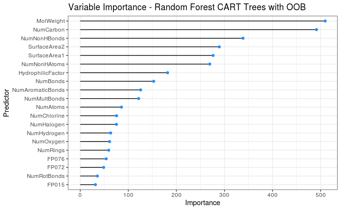

```r
final_fit5.2 <- fit(final_wf, df_train) %>%
  pull_workflow_fit()

varImp(final_fit5.2$fit) %>%
  filter(Overall > 0) %>%
  slice_max(Overall, n = 20) %>%
  rownames_to_column("var") %>%
  ggplot() +
  geom_segment(aes(x = 0, xend = Overall, y = reorder(var, Overall), yend = var)) +
  geom_point(aes(Overall, var), color = "dodgerblue") +
  labs(x = "Importance", y = "Predictor",
       title = "Variable Importance - Random Forest CART Trees with OOB")
```

## 8.6 Boosting

### Training Data

```r
# Model:
# tidymodels doesn't offer the gbm package. I am using xgboost instead. These are the equivalent parameters:
# interaction.depth = tree_depth; n.trees = trees; shrinkage = eta.
# n.minobsinnode from gbm is equivalent to min_n, but both of these are integers while the xgboost equivalent
# called min_child_weight is a real number (weight). I will leave this at the default for now.
boost_mod <-
  boost_tree(tree_depth = tune(), trees = tune(), learn_rate = tune()) %>%
  set_engine("xgboost") %>%
  set_mode("regression")

# Workflow:
workflow6 <-
  workflow() %>%
  add_model(spec = boost_mod) %>%
  add_recipe(recipe = rec1)

# Create a tuning grid with the same candidate values as the `caret` model (in `APM_8.R`):
boost_grid <- expand.grid(tree_depth = seq(1, 7, by = 2),
                          trees = seq(100, 1000, by = 50),
                          learn_rate = c(0.01, 0.1))

# Use `tune::tune_grid()` to combine the workflow and CV folds to fit the model on the training data:
## Read in cached results if available:
file1 <- "/home/brian/R/dir/APM/chapter8/data/boost_cv.RDS"
if (file.exists(file1)) {
  boost_cv <- readRDS(file1)
} else {
  boost_cv <-
    workflow6 %>%
    tune_grid(resamples = folds,
              grid = boost_grid,
              control = control_grid(save_pred = TRUE),
              metrics = metric_set(rmse, rsq))
  saveRDS(boost_cv, file1)
}
```

Plot metrics:

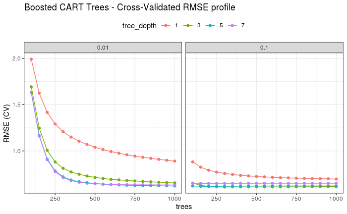

```r
boost_cv %>%
  collect_metrics() %>%
  filter(.metric == "rmse") %>%
  mutate(tree_depth = factor(tree_depth),
         learn_rate = factor(learn_rate)) %>%
  ggplot(aes(trees, mean, color = tree_depth)) +
  geom_point() +
  geom_line() +
  facet_wrap(~learn_rate) +
  labs(y = "RMSE (CV)", title = "Boosted CART Trees - Cross-Validated RMSE profile") +
  theme(legend.position = "top")
```

The results are very similar to the `caret` workflow and text (Fig. 8.20).

Select the best model and store the training error:

```r
boost_best <- boost_cv %>%
  select_best("rmse")

# Store the training error:
rmse_train <- boost_cv %>%
  show_best("rmse") %>%
  pluck("mean", 1)
```

### Testing Data

Fit a model using all of the training data and apply it to the test data:

```r
# Finalize the workflow by updating it to use the best model:
final_wf <-
  workflow6 %>%
  finalize_workflow(boost_best)

# This extracts the parameters in the final model (this code is clunky, could probably be made simpler):
wf <- final_wf %>% workflows::pull_workflow_spec()
tree_depth <- wf$args$tree_depth[2] %>% as.character()
trees <- wf$args$trees[2] %>% as.character()
learn_rate <- wf$args$learn_rate[2] %>% as.character()

# Fit the final model using all of the training data and evaluate using the test data:
boost_fit_final <-
  final_wf %>%
  last_fit(splits)

# Store test error:
rmse_test <- boost_fit_final %>%
  collect_metrics() %>%
  filter(.metric == "rmse") %>%
  pluck(".estimate")
```

Store the training and test RMSE values and parameters:

```r
RMSE_TM <- rbind(RMSE_TM,
                 c(framework = "tidymodels",
                   engine = "xgboost",
                   model = "Boosted CART Trees",
                   rmse_train = rmse_train,
                   rmse_test = rmse_test,
                   parameters = str_interp("tree_depth: ${tree_depth}; trees: ${trees}; learn_rate: ${learn_rate}")))
```

## 8.7 Cubist

### Training Data

```r
# Model:
cubist_mod <-
  cubist_rules(committees = tune(), neighbors = tune()) %>%
  set_mode("regression")

# Workflow:
workflow7 <-
  workflow() %>%
  add_model(spec = cubist_mod) %>%
  add_recipe(recipe = rec1)

# Create a tuning grid with the same candidate values as the `caret` model (in `APM_8.R`):
cubist_grid <- expand.grid(committees = c(1:10, 20, 50, 75, 100),
                           neighbors = c(0, 1, 5, 9))

# Use `tune::tune_grid()` to combine the workflow and CV folds to fit the model on the training data:
## Read in cached results if available:
file1 <- "/home/brian/R/dir/APM/chapter8/data/cubist_cv.RDS"
if (file.exists(file1)) {
  cubist_cv <- readRDS(file1)
} else {
  cubist_cv <-
    workflow7 %>%
    tune_grid(resamples = folds,
              grid = cubist_grid,
              control = control_grid(save_pred = TRUE),
              metrics = metric_set(rmse, rsq))
  saveRDS(cubist_cv, file1)
}
```

Plot metrics:

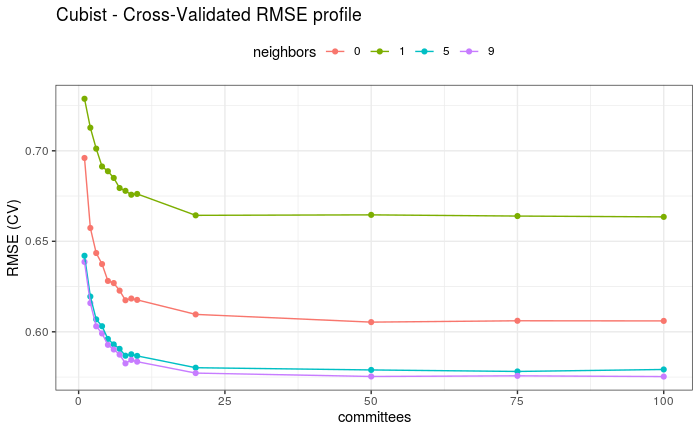

```r
cubist_cv %>%
  collect_metrics() %>%
  filter(.metric == "rmse") %>%
  mutate(neighbors = factor(neighbors)) %>%
  ggplot(aes(committees, mean, color = neighbors)) +
  geom_point() +
  geom_line() +
  labs(y = "RMSE (CV)", title = "Cubist - Cross-Validated RMSE profile") +
  theme(legend.position = "top")
```

The results are very similar to the `caret` workflow and text (Fig. 8.22).

Select the best model and store the training error:

```r
cubist_best <- cubist_cv %>%
  select_best("rmse")

# Store the training error:
rmse_train <- cubist_cv %>%
  show_best("rmse") %>%
  pluck("mean", 1)
```

### Testing Data

Fit a model using all of the training data and apply it to the test data:

```r
# Finalize the workflow by updating it to use the best model:
final_wf <-
  workflow7 %>%
  finalize_workflow(cubist_best)

# This extracts the parameters in the final model (this code is clunky, could probably be made simpler):
wf <- final_wf %>% workflows::pull_workflow_spec()
committees <- wf$args$committees[2] %>% as.character()
neighbors <- wf$args$neighbors[2] %>% as.character()

# Fit the final model using all of the training data and evaluate using the test data:
cubist_fit_final <-
  final_wf %>%
  last_fit(splits)

# Store test error:
rmse_test <- cubist_fit_final %>%
  collect_metrics() %>%
  filter(.metric == "rmse") %>%
  pluck(".estimate")
```

Store the training and test RMSE values and parameters:

```r
RMSE_TM <- rbind(RMSE_TM,
                 c(framework = "tidymodels",
                   engine = "Cubist",
                   model = "Cubist",
                   rmse_train = rmse_train,
                   rmse_test = rmse_test,
                   parameters = str_interp("committees: ${committees}; neighbors: ${neighbors}")))
```

### Variable Importance

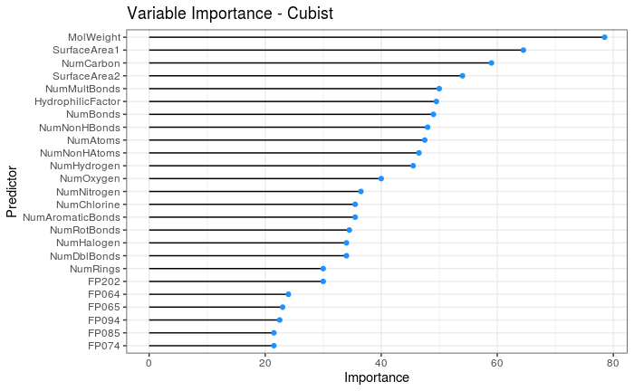

```r
final_fit7 <- fit(final_wf, df_train) %>%
  pull_workflow_fit()

varImp(final_fit7$fit) %>%
  filter(Overall > 0) %>%
  slice_max(Overall, n = 24) %>%
  rownames_to_column("var") %>%
  ggplot() +
  geom_segment(aes(x = 0, xend = Overall, y = reorder(var, Overall), yend = var)) +
  geom_point(aes(Overall, var), color = "dodgerblue") +
  labs(x = "Importance", y = "Predictor",
       title = "Variable Importance - Cubist")
```

## Metrics

View train and test errors:

```r
RMSE_TM %>%
  mutate(rmse_train = round(as.numeric(rmse_train), 3),
         rmse_test = round(as.numeric(rmse_test), 3))
```

| framework | engine | model | rmse_train | rmse_test | parameters |
| --- | --- | --- | --- | --- | --- |
| tidymodels | rpart | CART | 0.911 | 0.988 | cost_complexity: 0.002899 |
| tidymodels | rpart | Bagged CART | 0.659 | 0.672 | times: 50 |
| tidymodels | randomForest | Random Forest CART Trees - CV | 0.656 | 0.652 | mtry: 82 |
| tidymodels | randomForest | Random Forest CART Trees - OOB | 0.697 | 0.653 | mtry: 58 |
| tidymodels | xgboost | Boosted CART Trees | 0.610 | 0.601 | tree_depth: 3; trees: 300; learn_rate: 0.1 |
| tidymodels | Cubist | Cubist | 0.575 | 0.551 | committees: 100; neighbors: 9 |

[^1]: Kuhn M, Johnson K (2013). *Applied Predictive Modeling*. Springer.